# Tema 3. Flujo de datos

Programación en Tecnologías de la Información Geográfica · Máster Universitario en Tecnologías de la Información Geográfica

Author

Paloma Ruiz Benito, Verónica Cruz Alonso, Julián Tijerín Triviño

Published

21/10/2026

## 0.1 Objetivos Tema3: Flujo y control

- Organizando datos: gramática de datos (📝)
- Visualización de datos: ggplot (🧑‍🎓 )

# 1 Los básicos: datos y la estética del gráfico.

**`ggplot2`** es uno de los paquetes más utilizados en *R* para la visualización de datos dentro del ecosistema tidyverse, un conjunto de paquetes diseñados para trabajar con datos de forma coherente, eficiente y reproducible. **`gplot2`** se basa en la *Grammar of Graphics*, una filosofía que entiende los gráficos como la combinación de componentes bien definidos: los datos, las variables que se representan (*aesthetics*), las formas geométricas que las visualizan, las escalas y el contexto visual. Esta lógica resulta especialmente útil en áreas donde se manejen una gran cantidad de información, donde usualmente se trabaja con datasets multidimensionales, heterogéneos y, a menudo, espaciales o temporales.

[figure not shown]

En lugar de “dibujar” un gráfico de una sola vez, **`ggplot2`** nos invita a construirlo por capas, añadiendo información de manera progresiva. Este enfoque favorece la exploración de los datos, permite modificar y reutilizar gráficos con facilidad. Un mismo conjunto de datos puede representarse de múltiples maneras simplemente cambiando una capa o una estética, lo que resulta ideal para comparar escenarios, periodos temporales o gradientes ambientales.

¿Qué hace que una visualización de un gráfico sea buena? No depende ñunicamente de que sea visualmente atractivo, sino de dos dimensiones fundamentales:

- La **EJECUCIÓN**, es decir, cómo de bien construido está el gráfico desde el punto de vista técnico y visual (claridad, legibilidad, coherencia), y
- La **ADECUACIÓN**, que responde a preguntas clave como qué queremos comunicar, a quién va dirigido, con qué objetivo y en qué contexto se va a utilizar.

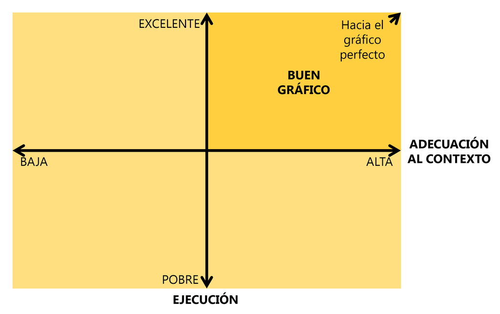

Conceptual framework of a “good graphic,” considering both execution (how well it is constructed) and appropriateness (what is being communicated, to whom, where, and why). Adapted from Good Charts by Scott Berinato.

Primero de todo, tenemos que realizar la **instalación y carga los paquetes necesarios** si aún no los tenemos. Vamos a seguir trabajando con los datos de Palmer Penguins. Donde tenemos las medidas de especies de pinguimos de la Isla de Palmer.

```r
library(palmerpenguins)
library(tidyverse)
library(GGally)
glimpse(penguins)
```

```
Rows: 344
Columns: 8
$ species           <fct> Adelie, Adelie, Adelie, Adelie, Adelie, Adelie, Adel…
$ island            <fct> Torgersen, Torgersen, Torgersen, Torgersen, Torgerse…
$ bill_length_mm    <dbl> 39.1, 39.5, 40.3, NA, 36.7, 39.3, 38.9, 39.2, 34.1, …
$ bill_depth_mm     <dbl> 18.7, 17.4, 18.0, NA, 19.3, 20.6, 17.8, 19.6, 18.1, …
$ flipper_length_mm <int> 181, 186, 195, NA, 193, 190, 181, 195, 193, 190, 186…
$ body_mass_g       <int> 3750, 3800, 3250, NA, 3450, 3650, 3625, 4675, 3475, …
$ sex               <fct> male, female, female, NA, female, male, female, male…
$ year              <int> 2007, 2007, 2007, 2007, 2007, 2007, 2007, 2007, 2007…
```

La visualización exploratoria de datos es una etapa fundamental en cualquier análisis . Una visualización bien construida debe ser clara, tener ejes etiquetados apropiadamente, incluir un título descriptivo, una leyenda legible cuando sea necesario, y siempre indicar las unidades de medida. El paquete `ggplot2` implementa la *Grammar of Graphics* (Gramática de los Gráficos), un sistema coherente y estructurado para construir visualizaciones de nuestros datos. Esta gramática se compone de varios elementos fundamentales: **datos** + **aesthetics** + **geometrías** + **opciones adicionales**, que se combinan de forma modular para crear gráficos complejos.